# QR WEEK 7: ZONING CLUSTERS ANALYSIS

2022-11-01

#### Part I

What are different ways in which two variables might be correlated (i.e. direct causation, codetermination, etc…) ? Please give one example for each.

ANSWER: direct causation: cookies are very sweet because it contains a lot of sugar (sweetness of cookie vs amount of sugar added) codetermination: more butter and flour will make cookies have higher calorie (calorie vs amount of different ingredients’ energy ) reverse causation: sweetness of cookie decreases because of the increase amount of flour used (sweetness of cookie vs amount of flour) hidden variables (confounders): adding more sugar to cookie will increase the calorie and increase the sweetness

#### Part II

The output of the bivariate regression of Home Energy Rating System (HERS) Index score on annual utility cost per square foot, for our sample of 20,452 homes with HERS ratings, tells us that there is a constant of 0.634 and a coefficient of 0.006.

2)(a) Write the equation for this bivariate regression. y = bx + k y = 0.006x + 0.634

x = Annual utility cost per square foot y = Index score

2(b) A one unit increase in the HERS index score is associated with how much change in the annual utility costs for a 2,000 sf home? 1 = 0.006x

```r
x=1/0.006
x*2000
```

```
## [1] 333333.3
```

#### Part III

##### Setting up working environment

```
##
##
##
## Learn more about sjPlot with 'browseVignettes("sjPlot")'.
```

```r
femaclaim <- read.csv("fema_claims_random.csv")
```

#### We would like to know the relationship between the total amount of building claims (variable: amountpaidonbuildingclaim) and the types of Elevation Certificate (variable: elevationcertificateindicator).

1. Create a bar plot of types of certificates (hint: In order for the elevation certificate variable to be read as categorical data, you need to convert the variable as factor).
2. Plot the histogram of the amount paid on building claims.
3. Write out the equation for the fitted model.
4. Plot the relationship between two variables (hint: make sure you exclude NAs before you plot).
5. Fit the model and paste the result.
6. In a short paragraph, describe how these two variables are associated. Make sure to explicitly discuss and interpret each coefficient (the hypothesis testing using t-stats and p-value) and R2.
7. If you could add variables to increase the explanatory power of the model, what variable would you want to add? Why?

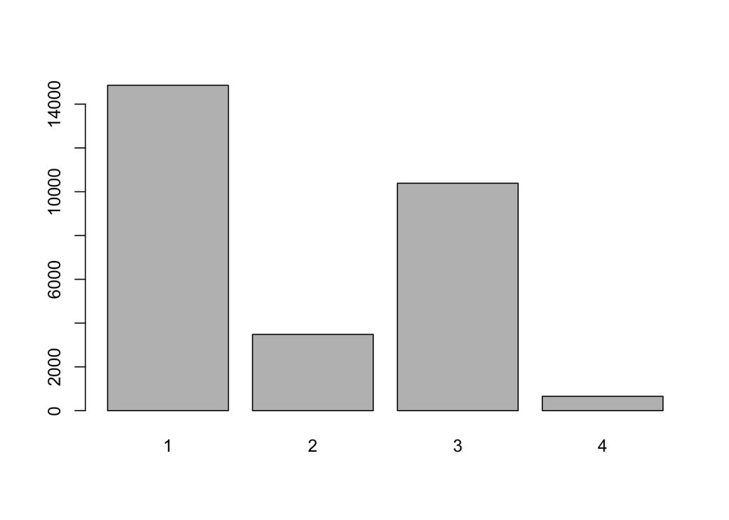

```r
ec <-
  femaclaim$elevationcertificateindicator %>%
  na.omit() %>%
  as.factor() %>%
  plot()
```

2. Plot the histogram of the amount paid on building claims.

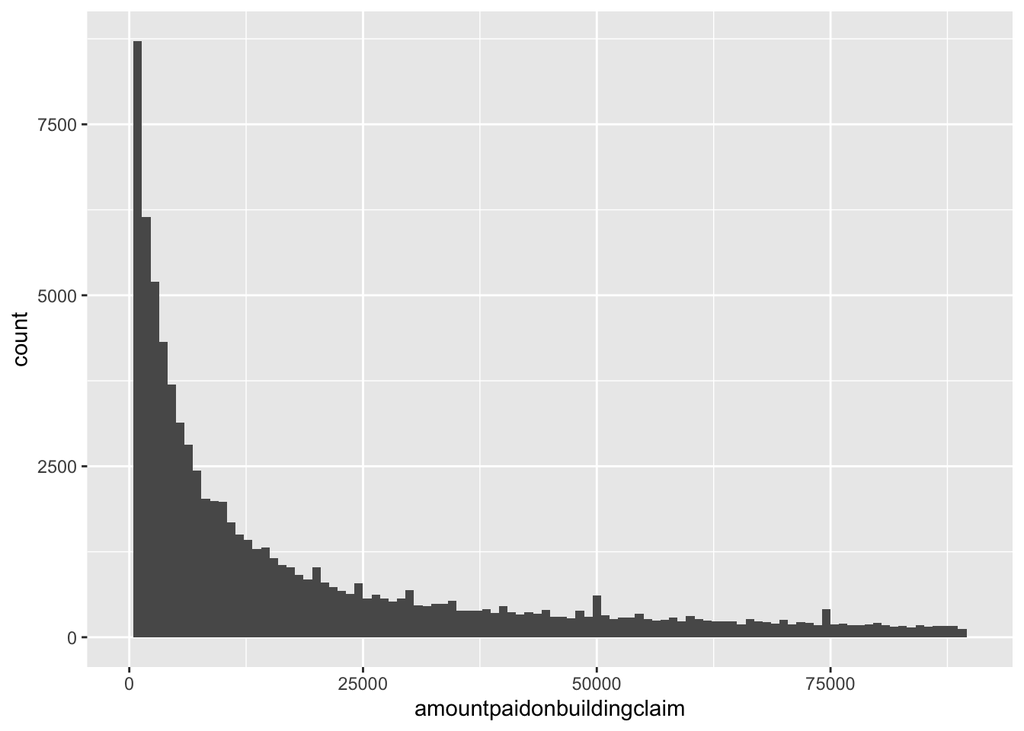

```r
bc <- (na.omit(femaclaim$amountpaidonbuildingclaim))

femaclaim %>%
  ggplot(aes(amountpaidonbuildingclaim, na.rm = TRUE))+
  geom_histogram(bins = 100)+
  xlim(0, 90000)
```

3. Write out the equation for the fitted model. buildingclaim = coefficient*elevationcertificateindicator + constant y = 31,322.1-9314.2(x_2 )+8661.3(x_3 )+ 6015.5(x_4) + ε

4. Plot the relationship between two variables (hint: make sure you exclude NAs before you plot).

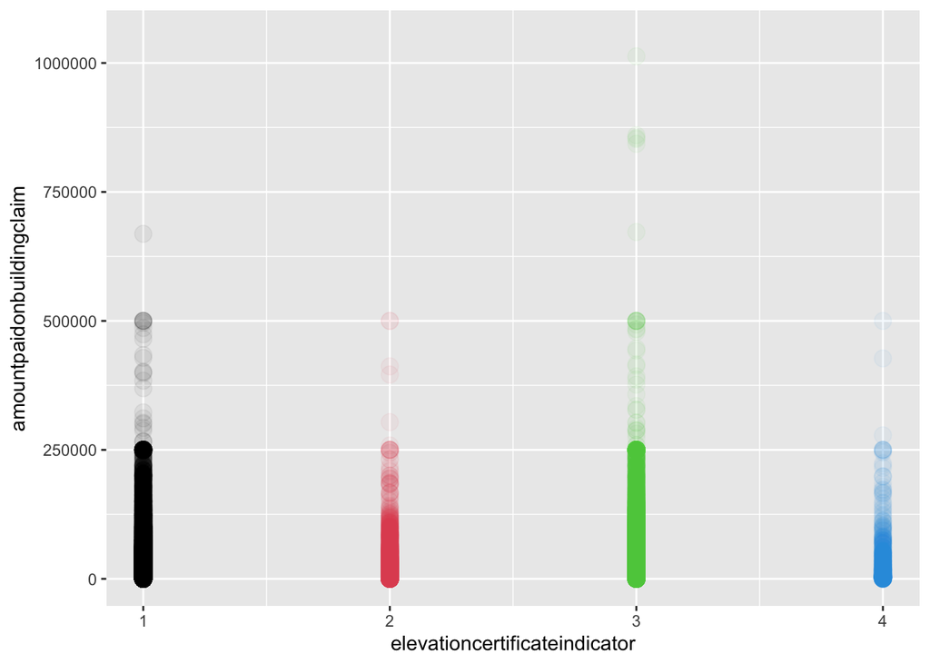

```r
cor <- femaclaim %>%
  ggplot (aes(x=elevationcertificateindicator, y=amountpaidonbuildingclaim)) +
  ylim(1,1050000) +
  geom_point(color = as.factor(femaclaim$elevationcertificateindicator), alpha = 0.05, size = 4, fill = "white")

cor
```

5. Fit the model and paste the result.

```r
lm <- lm(amountpaidonbuildingclaim~as.factor(elevationcertificateindicator), data = femaclaim)
summary(lm)
```

```
##
## Call:
## lm(formula = amountpaidonbuildingclaim ~ as.factor(elevationcertificateindicator),
##     data = femaclaim)
##
## Residuals:
##    Min     1Q Median     3Q    Max
## -39983 -28888 -18363  10397 972957
##
## Coefficients:
##                                           Estimate Std. Error t value Pr(>|t|)
## (Intercept)                                31322.1      473.8  66.110  < 2e-16
## as.factor(elevationcertificateindicator)2  -9314.2     1115.6  -8.349  < 2e-16
## as.factor(elevationcertificateindicator)3   8661.3      750.7  11.538  < 2e-16
## as.factor(elevationcertificateindicator)4   6015.5     2331.5   2.580  0.00989
##
## (Intercept)                               ***
## as.factor(elevationcertificateindicator)2 ***
## as.factor(elevationcertificateindicator)3 ***
## as.factor(elevationcertificateindicator)4 **
## ---
## Signif. codes:  0 '***' 0.001 '**' 0.01 '*' 0.05 '.' 0.1 ' ' 1
##
## Residual standard error: 50690 on 22032 degrees of freedom
##   (106483 observations deleted due to missingness)
## Multiple R-squared:  0.01243,    Adjusted R-squared:  0.01229
## F-statistic: 92.42 on 3 and 22032 DF,  p-value: < 2.2e-16
```

6. In a short paragraph, describe how these two variables are associated. Make sure to explicitly discuss and interpret each coefficient (the hypothesis testing using t-stats and p-value) and R2.

7. If you could add variables to increase the explanatory power of the model, what variable would you want to add? Why? Since we are looking at elevation certificate’s relationship with building claim, I would also water to add elevation difference in this model

#### Now we want to see the relationship between the total amount of contents claims (variable: amountpaidoncontentsclaim) and the elevation of the lowest floor (variable: lowestfloorelevation).

Plot the histogram of the total amount of insurance claims for contents.

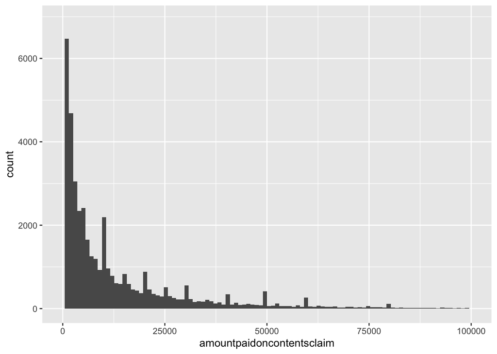

```r
ggplot(femaclaim, aes(x = amountpaidoncontentsclaim, na.rm = TRUE)) + geom_histogram(bins=100) + xlim(0,100000)
```

Plot the histogram of the elevation of the lowest floors.

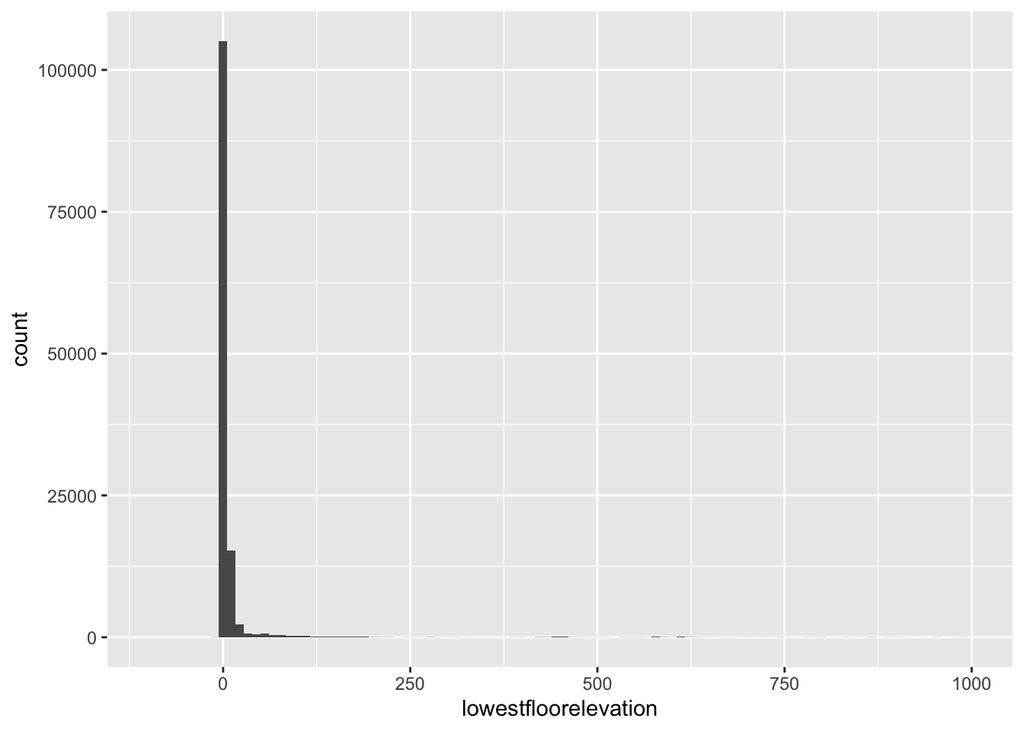

```r
#whole range
ggplot(femaclaim, aes(x = lowestfloorelevation, na.rm = TRUE)) + geom_histogram(bins = 100) + xlim(-100,1000)
```

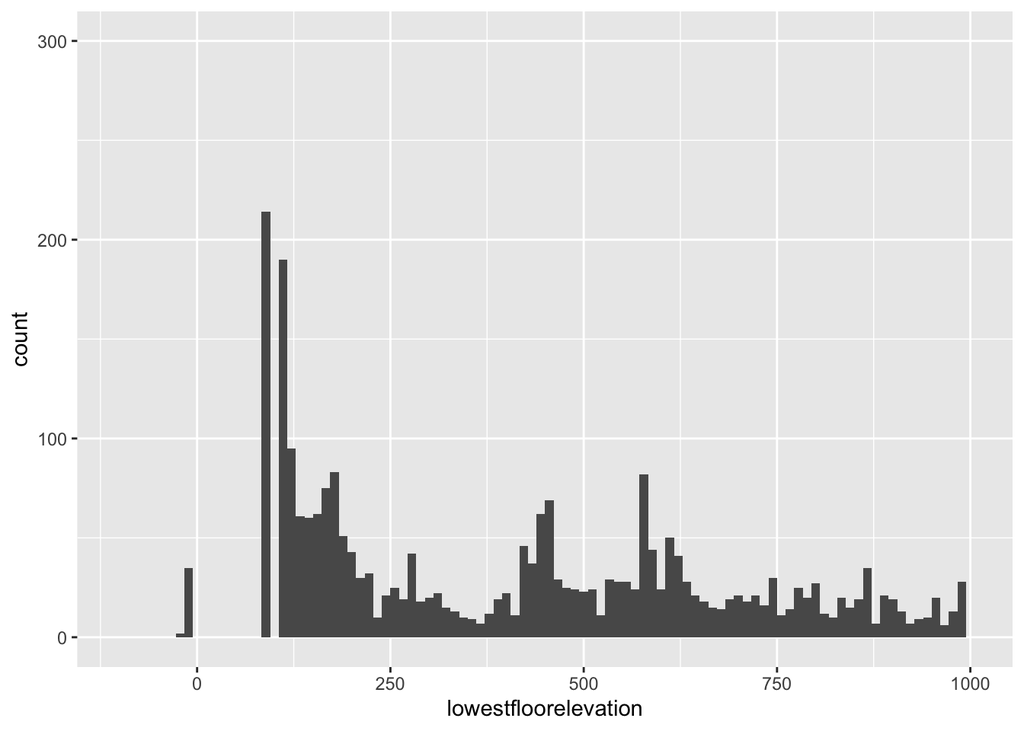

```r
#focused range with y limit
ggplot(femaclaim, aes(x = lowestfloorelevation, na.rm = TRUE)) + geom_histogram(bins = 100) + xlim(-100,1000)+ylim(0,300)
```

Write out the equation for the fitted model.

-total amount of contents claims (variable: amountpaidoncontentsclaim) = intercept + coefficient * elevation of the lowest floor (variable: lowestfloorelevation)

Plot the relationship between two variables.

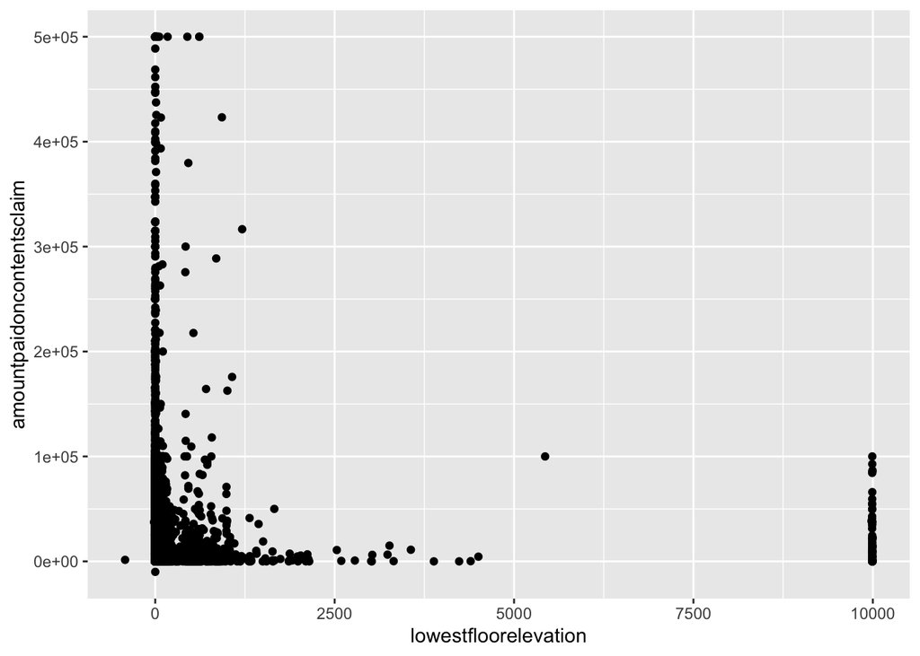

```r
femaclaim %>%
  select(amountpaidoncontentsclaim, lowestfloorelevation) %>%
  na.omit() %>%
  ggplot(aes(x=lowestfloorelevation, y=amountpaidoncontentsclaim)) + geom_point()
```

Fit the model and paste the result.

```r
lm_2 <- lm(amountpaidoncontentsclaim~lowestfloorelevation, data = femaclaim)
summary(lm_2)
```

```
##
## Call:
## lm(formula = amountpaidoncontentsclaim ~ lowestfloorelevation,
##     data = femaclaim)
##
## Residuals:
##    Min     1Q Median     3Q    Max
## -25827 -12837  -9120   1416 485880
##
## Coefficients:
##                       Estimate Std. Error t value Pr(>|t|)
## (Intercept)          1.412e+04  1.300e+02 108.575  < 2e-16 ***
## lowestfloorelevation 1.171e+00  3.377e-01   3.468 0.000526 ***
## ---
## Signif. codes:  0 '***' 0.001 '**' 0.01 '*' 0.05 '.' 0.1 ' ' 1
##
## Residual standard error: 28760 on 49130 degrees of freedom
##   (79387 observations deleted due to missingness)
## Multiple R-squared:  0.0002447,  Adjusted R-squared:  0.0002243
## F-statistic: 12.02 on 1 and 49130 DF,  p-value: 0.0005258
```

In a short paragraph, describe how these two variables are associated. Make sure to explicitly discuss and interpret each coefficient (the hypothesis testing using t-stats and p-value) and R2.

If you could add variables to increase the explanatory power of the model, what variable would you want to add? Why?

-I would include the number of floors in the insured building, because this model concerns with the floor levels’ relationship with amount of claim for contents